# Generalized Additive Model

# 1 Generalized Additive Model

There are two common implementations of GAMs in R. The older version (originally made for S-PLUS) is available as the ‘gam’ package by Hastie and Tibshirani. The newer version that we will use below is the ‘mgcv’ package from Simon Wood. The basic modeling procedure for both packages is similar (the function is gam for both; be wary of having both libraries loaded at the same time), but the behind-the-scenes computational approaches differ, as do the arguments for optimization and the model output. Expect the results to be slightly different when used with the same model structure on the same dataset.

## 1.1 GAM on Boston Housing dataset

```r
library(MASS)
set.seed(1234)
sample_index <- sample(nrow(Boston),nrow(Boston)*0.70)
Boston_train <- Boston[sample_index,]
Boston_test <- Boston[-sample_index,]
str(Boston_train)
```

**Model and plots**

```r
library(mgcv)

#create gam model
Boston_gam <- gam(medv ~ s(crim)+s(zn)+s(indus)+chas+s(nox)
                 +s(rm)+s(age)+s(dis)+rad+s(tax)+s(ptratio)
                 +s(black)+s(lstat),data=Boston_train)

summary(Boston_gam)
```

```
##
## Family: gaussian
## Link function: identity
##
## Formula:
## medv ~ s(crim) + s(zn) + s(indus) + chas + s(nox) + s(rm) + s(age) +
##     s(dis) + rad + s(tax) + s(ptratio) + s(black) + s(lstat)
##
## Parametric coefficients:
##             Estimate Std. Error t value Pr(>|t|)
## (Intercept)  18.9672     1.4638  12.958   <2e-16 ***
## chas          1.0098     0.7104   1.421   0.1562
## rad           0.3454     0.1505   2.296   0.0224 *
## ---
## Signif. codes:  0 '***' 0.001 '**' 0.01 '*' 0.05 '.' 0.1 ' ' 1
##
## Approximate significance of smooth terms:
##              edf Ref.df      F  p-value
## s(crim)    4.543  5.488  7.436 6.38e-07 ***
## s(zn)      1.000  1.000  0.973 0.324644
## s(indus)   6.701  7.629  4.124 0.000171 ***
## s(nox)     8.946  8.995 17.931  < 2e-16 ***
## s(rm)      7.792  8.605 19.944  < 2e-16 ***
## s(age)     2.415  3.058  1.302 0.282947
## s(dis)     8.742  8.975  8.895 4.36e-12 ***
## s(tax)     6.122  7.145  7.091 7.01e-08 ***
## s(ptratio) 1.000  1.000 21.257 5.90e-06 ***
## s(black)   1.000  1.000  0.002 0.963662
## s(lstat)   6.362  7.484 18.551  < 2e-16 ***
## ---
## Signif. codes:  0 '***' 0.001 '**' 0.01 '*' 0.05 '.' 0.1 ' ' 1
##
## R-sq.(adj) =  0.893   Deviance explained =   91%
## GCV = 10.713  Scale est. = 8.9693    n = 354
```

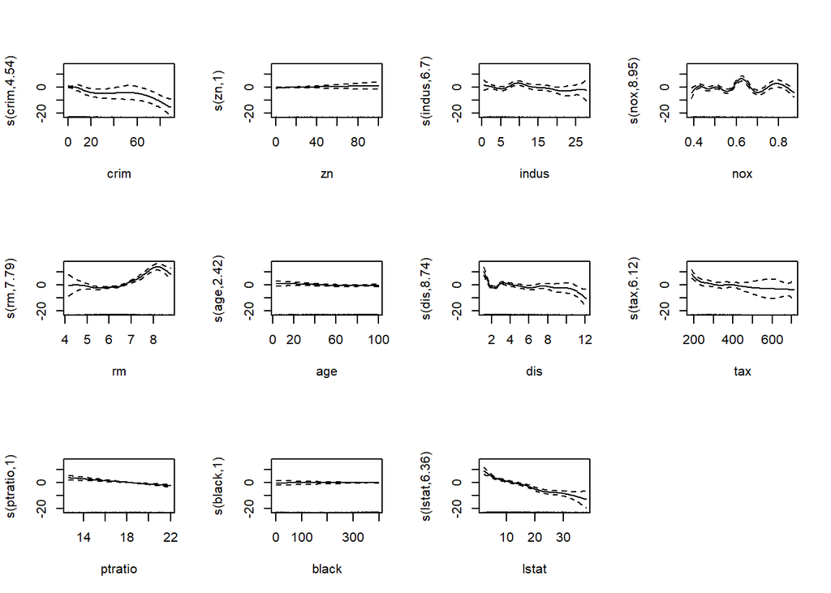

```r
plot(Boston_gam, pages=1)
```

**Model AIC/BIC and mean residual deviance**

```r
AIC(Boston_gam)
BIC(Boston_gam)
Boston_gam$deviance
```

[output not shown]

**In-sample fit performance**

```r
#in-sample mse using df
Boston_gam.mse.train <- Boston_gam$dev/Boston_gam$df.residual
#Average Sum of Squared Error
Boston_gam.mse.train <- Boston_gam$dev/nrow(Boston_train)

#using the predict() function
pi <- predict(Boston_gam,Boston_train)
mean((pi - Boston_train$medv)^2)
```

```
## [1] 7.509325
```

**out of sample performance**

```r
pi.out <- predict(Boston_gam,Boston_test)
mean((pi.out - Boston_test$medv)^2)
```

```
## [1] 14.04571
```

go to top

## 1.2 GAM on Bankruptcy dataset

```r
Bank_data <- read.csv(file = "https://xiaoruizhu.github.io/Data-Mining-R/lecture/data/bankruptcy.csv", header=T)
# summary(Bank_data)

sample_index <- sample(nrow(Bank_data),nrow(Bank_data)*0.70)
Bank_train <- Bank_data[sample_index,]
Bank_test <- Bank_data[-sample_index,]
```

**Model and plots**

```r
Bank_gam <- gam(DLRSN ~ s(R1)+s(R2)+s(R3)+s(R4)+
                  s(R5)+s(R6)+s(R7)+s(R8)+s(R9)+s(R10), data=Bank_train)

summary(Bank_gam)
```

```
##
## Family: gaussian
## Link function: identity
##
## Formula:
## DLRSN ~ s(R1) + s(R2) + s(R3) + s(R4) + s(R5) + s(R6) + s(R7) +
##     s(R8) + s(R9) + s(R10)
##
## Parametric coefficients:
##             Estimate Std. Error t value Pr(>|t|)
## (Intercept) 0.139028   0.004601   30.21   <2e-16 ***
## ---
## Signif. codes:  0 '***' 0.001 '**' 0.01 '*' 0.05 '.' 0.1 ' ' 1
##
## Approximate significance of smooth terms:
##          edf Ref.df      F  p-value
## s(R1)  1.000  1.000  0.553   0.4571
## s(R2)  4.227  5.204 25.941  < 2e-16 ***
## s(R3)  2.125  2.723  8.647 5.27e-05 ***
## s(R4)  1.000  1.000  5.893   0.0153 *
## s(R5)  6.630  7.743  2.379   0.0140 *
## s(R6)  4.501  5.568 22.453  < 2e-16 ***
## s(R7)  1.000  1.000  0.788   0.3749
## s(R8)  6.564  7.670  9.507 1.68e-12 ***
## s(R9)  4.046  5.069 14.335 5.31e-14 ***
## s(R10) 5.621  6.770 50.329  < 2e-16 ***
## ---
## Signif. codes:  0 '***' 0.001 '**' 0.01 '*' 0.05 '.' 0.1 ' ' 1
##
## R-sq.(adj) =  0.327   Deviance explained = 33.4%
## GCV = 0.08137  Scale est. = 0.080564  n = 3805
```

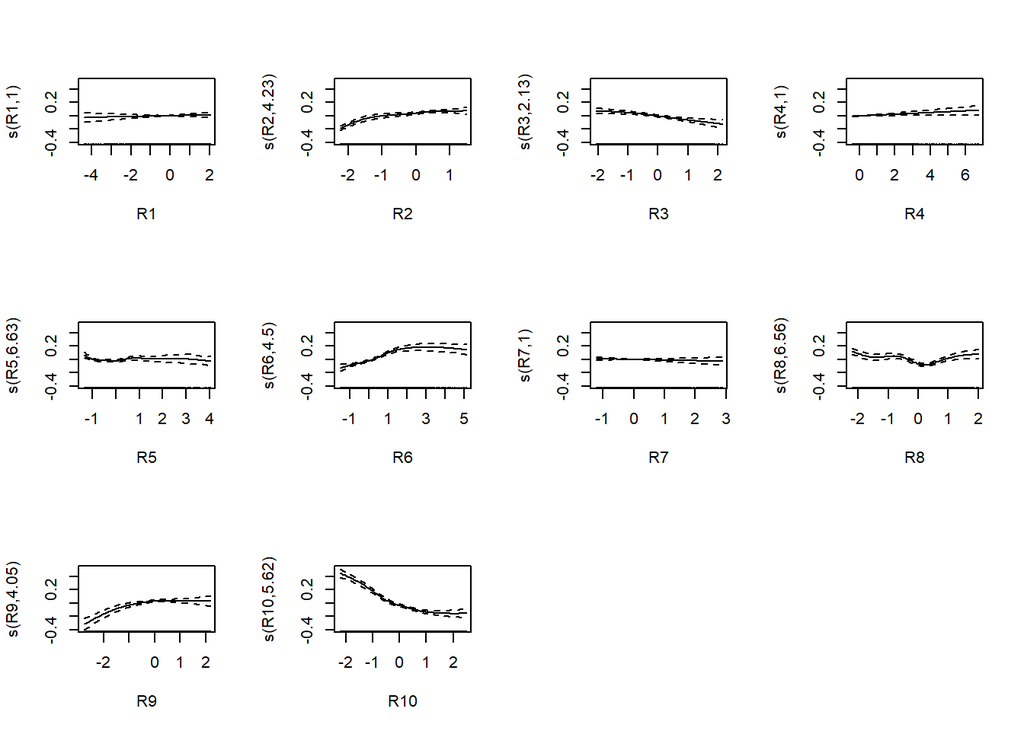

```r
plot(Bank_gam, pages=1)
```

**In-sample fit performance**

```r
pcut_gam <- .15
prob_gam_in <-predict(Bank_gam, Bank_train, type="response")
pred_gam_in <- (prob_gam_in>=pcut_gam)*1
table(Bank_train$DLRSN, pred_gam_in, dnn=c("Observed","Predicted"))
```

```
##         Predicted
## Observed    0    1
##        0 2422  854
##        1   64  465
```

Likewise, misclassification rate is another thing you can check:

```r
mean(ifelse(Bank_train$DLRSN != pred_gam_in, 1, 0))
```

```
## [1] 0.2412615
```

**Model AIC/BIC and mean residual deviance**

```r
AIC(Bank_gam)
```

```
## [1] 1253.97
```

```r
BIC(Bank_gam)
```

```
## [1] 1495.704
```

```r
#in-sample mean residual deviance using df
Bank_gam$dev/Bank_gam$df.residual
```

```
## [1] 0.08056376
```

**Out-of-sample fit performance**

```r
prob_gam_out <- predict(Bank_gam, Bank_test, type="response")
pred_gam_out <- (prob_gam_out>=pcut_gam)*1
table(Bank_test$DLRSN, pred_gam_out, dnn=c("Observed","Predicted"))
```

```
##         Predicted
## Observed    0    1
##        0 1013  371
##        1   35  212
```

The mis-classifciation rate is

```r
mean(ifelse(Bank_test$DLRSN != pred_gam_out, 1, 0))
```

```
## [1] 0.248927
```

go to top

## 1.3 GAM on Credit Scoring Data

```r
credit_data <- read.csv(file = "https://xiaoruizhu.github.io/Data-Mining-R/lecture/data/credit_default.csv", header=T)

# rename
library(dplyr)
credit_data<- rename(credit_data, default=default.payment.next.month)
# convert categorical data to factor
credit_data$SEX<- as.factor(credit_data$SEX)
credit_data$EDUCATION<- as.factor(credit_data$EDUCATION)
credit_data$MARRIAGE<- as.factor(credit_data$MARRIAGE)
```

Now split the data 90/10 as training/testing datasets:

```r
index <- sample(nrow(credit_data),nrow(credit_data)*0.90)
credit_train = credit_data[index,]
credit_test = credit_data[-index,]
```

The training dataset has 24 variables, 10800 obs.

You are already familiar with the credit scoring set. Let’s define a cost function for benchmarking testing set performance.

```r
## Create a formula for a model with a large number of variables:
gam_formula <- as.formula(paste("default~s(LIMIT_BAL)+s(AGE)+s(PAY_0)+s(BILL_AMT1)+s(PAY_AMT1)+",
                                paste(colnames(credit_train)[c(2:4)], collapse= "+")))

credit_gam <- gam(formula = gam_formula, family=binomial, data=credit_train);
summary(credit_gam)
```

```
##
## Family: binomial
## Link function: logit
##
## Formula:
## default ~ s(LIMIT_BAL) + s(AGE) + s(PAY_0) + s(BILL_AMT1) + s(PAY_AMT1) +
##     SEX + EDUCATION + MARRIAGE
##
## Parametric coefficients:
##              Estimate Std. Error z value Pr(>|z|)
## (Intercept) -1.217750   0.067325 -18.088  < 2e-16 ***
## SEX2        -0.175662   0.053552  -3.280  0.00104 **
## EDUCATION2  -0.046877   0.061423  -0.763  0.44535
## EDUCATION3  -0.218309   0.083468  -2.615  0.00891 **
## EDUCATION4  -1.204359   0.306518  -3.929 8.52e-05 ***
## MARRIAGE2   -0.117430   0.060287  -1.948  0.05143 .
## MARRIAGE3   -0.007125   0.234567  -0.030  0.97577
## ---
## Signif. codes:  0 '***' 0.001 '**' 0.01 '*' 0.05 '.' 0.1 ' ' 1
##
## Approximate significance of smooth terms:
##                edf Ref.df   Chi.sq  p-value
## s(LIMIT_BAL) 5.382  6.283  133.792  < 2e-16 ***
## s(AGE)       1.330  1.595    3.418 0.094709 .
## s(PAY_0)     6.714  7.454 1207.921  < 2e-16 ***
## s(BILL_AMT1) 3.827  4.780   47.780  4.1e-09 ***
## s(PAY_AMT1)  5.199  6.402   26.454 0.000282 ***
## ---
## Signif. codes:  0 '***' 0.001 '**' 0.01 '*' 0.05 '.' 0.1 ' ' 1
##
## R-sq.(adj) =  0.198   Deviance explained = 16.8%
## UBRE = -0.11427  Scale est. = 1         n = 10800
```

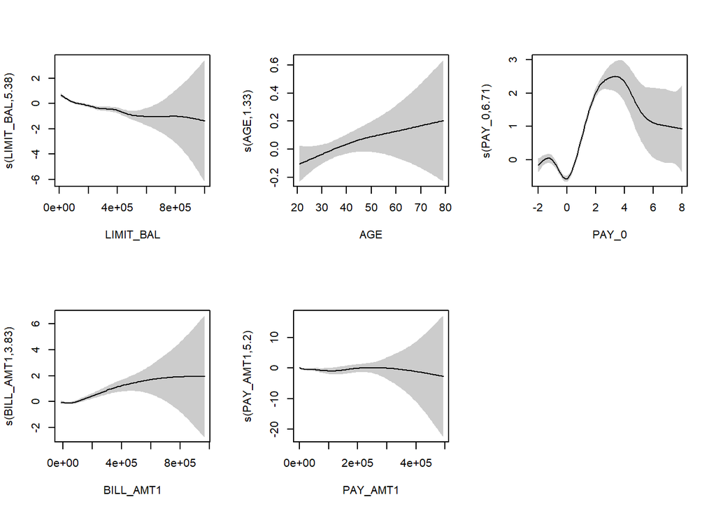

```r
plot(credit_gam, shade=TRUE, seWithMean=TRUE, scale=0, pages = 1)
```

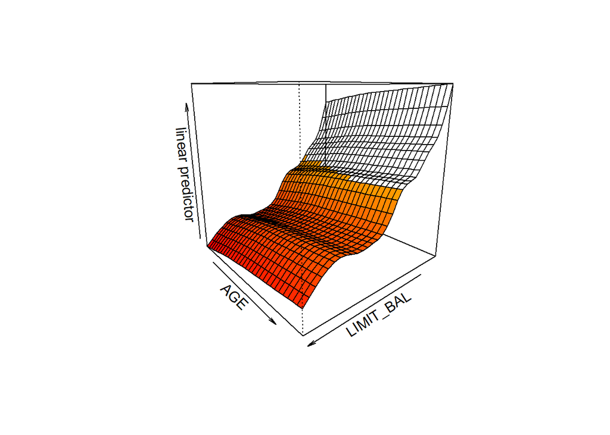

```r
# vis.gam(credit_gam)
vis.gam(credit_gam, view=c("LIMIT_BAL","AGE"), theta= 140) # different view
```

### 1.3.1 In-sample fit performance

In order to see the in-sample fit performance, you may look into the confusion matrix by using commands as following.

```r
pcut_gam <- .15
prob_gam_in <-predict(credit_gam,credit_train,type="response")
pred_gam_in <- (prob_gam_in>=pcut_gam)*1
table(credit_train$default, pred_gam_in,dnn=c("Observed","Predicted"))
```

```
##         Predicted
## Observed    0    1
##        0 4749 3656
##        1  539 1856
```

Likewise, misclassification rate is another thing you can check:

```r
mean(ifelse(credit_train$default != pred_gam_in, 1, 0))
```

```
## [1] 0.3884259
```

Training model AIC, BIC, and mean residual deviance:

```r
AIC(credit_gam)
```

```
## [1] 9565.864
```

```r
BIC(credit_gam)
```

```
## [1] 9780.494
```

```r
credit_gam$deviance
```

```
## [1] 9506.959
```

[figure not shown]

[output not shown]

```
## searchgrid
##       0.16
```

### 1.3.2 Out-of-sample fit performance

```r
pcut <-  result_gam[index_min,1]
prob_gam_out <- predict(credit_gam, credit_test,type="response")
pred_gam_out <- (prob_gam_out>=pcut)*1
table(credit_test$default, pred_gam_out,dnn=c("Observed","Predicted"))
```

```
##         Predicted
## Observed   0   1
##        0 599 364
##        1  56 181
```

The mis-classifciation rate is

```r
mean(ifelse(credit_test$default != pred_gam_out, 1, 0))
```

```
## [1] 0.35
```

The cost associated with misclassification is

```r
creditcost <- function(observed, predicted){
  weight1 = 5
  weight0 = 1
  c1 = (observed==1)&(predicted == 0) #logical vector - true if actual 1 but predict 0
  c0 = (observed==0)&(predicted == 1) #logical vector - true if actual 0 but predict 1
  return(mean(weight1*c1+weight0*c0))
}
creditcost(credit_test$default, pred_gam_out)
```

```
## [1] 0.5366667
```

go to top

## 1.4 GAM using the “Motorcycle” dataset

```r
library(MASS)
data('mcycle')
str(mcycle)
summary(mcycle)
```

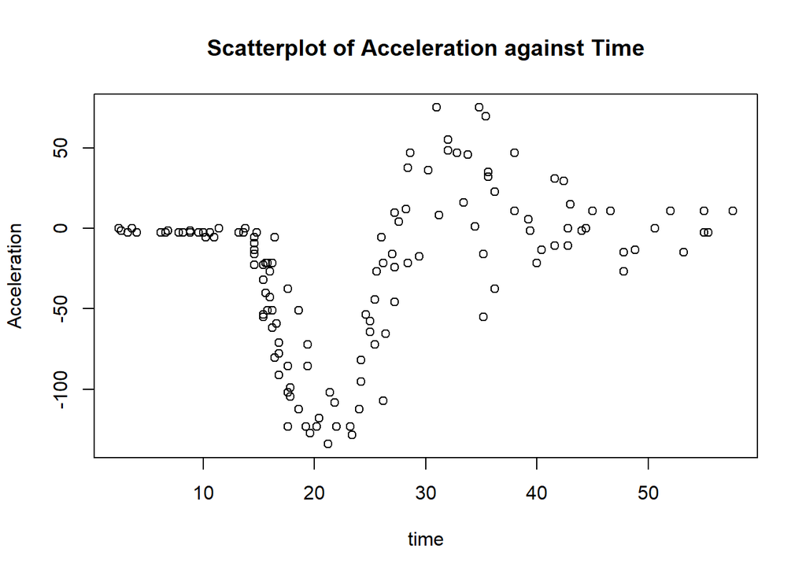

```r
# Rename the variables for ease of usage
Y <- mcycle$accel
X <- mcycle$times

#Scatterplot
plot(Y~X, xlab="time",ylab="Acceleration", main="Scatterplot of Acceleration against Time")
```

```r
library(mgcv)
s_gam <- gam(Y ~ s(X),data=mcycle)
summary(s_gam)
```

```
##
## Family: gaussian
## Link function: identity
##
## Formula:
## Y ~ s(X)
##
## Parametric coefficients:
##             Estimate Std. Error t value Pr(>|t|)
## (Intercept)  -25.546      1.951   -13.1   <2e-16 ***
## ---
## Signif. codes:  0 '***' 0.001 '**' 0.01 '*' 0.05 '.' 0.1 ' ' 1
##
## Approximate significance of smooth terms:
##        edf Ref.df     F p-value
## s(X) 8.693  8.972 53.52  <2e-16 ***
## ---
## Signif. codes:  0 '***' 0.001 '**' 0.01 '*' 0.05 '.' 0.1 ' ' 1
##
## R-sq.(adj) =  0.783   Deviance explained = 79.8%
## GCV = 545.78  Scale est. = 506       n = 133
```

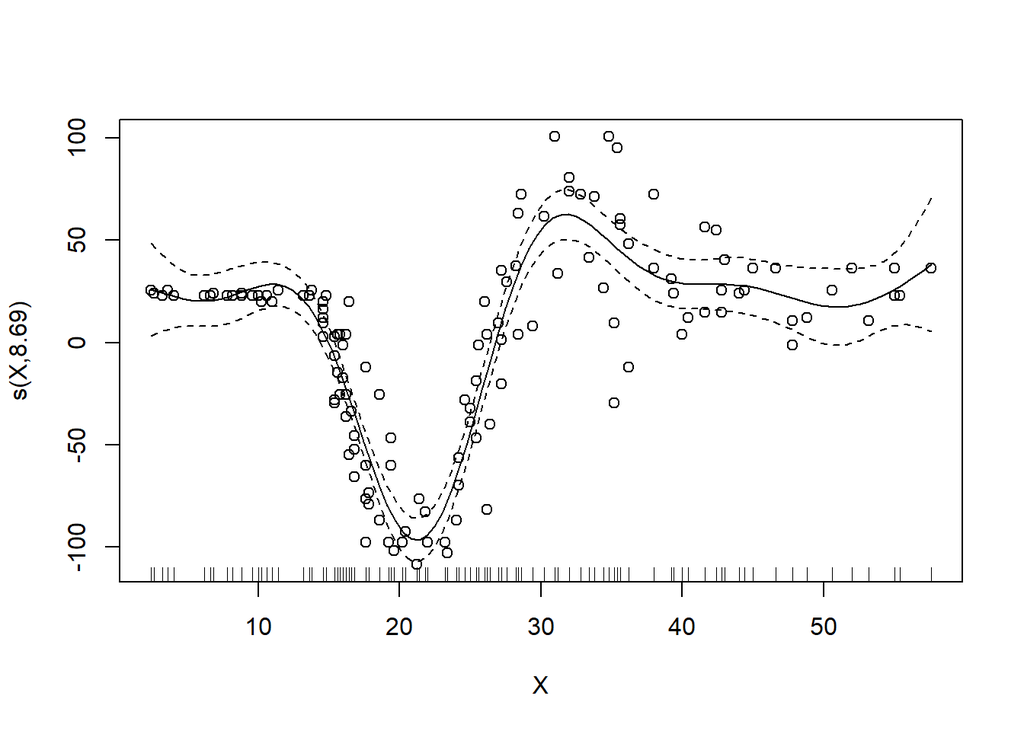

```r
#plot the model
plot(s_gam, residuals = TRUE, pch = 1)
```

go to top

## 1.5 GAM on “Wage” dataset

This dataset contains Wage and other data for a group of 3,000 male workers in the Mid-Atlantic region. First we conduct EDA and fit a multiple linear regression of wage on age, year, and education.

```r
require(ISLR)
attach(Wage)
# ?Wage
dim(Wage)
```

```
## [1] 3000   11
```

```r
s_Wage <- Wage[c("age","year","education","wage")]
str(s_Wage)
```

```
## 'data.frame':    3000 obs. of  4 variables:
##  $ age      : int  18 24 45 43 50 54 44 30 41 52 ...
##  $ year     : int  2006 2004 2003 2003 2005 2008 2009 2008 2006 2004 ...
##  $ education: Factor w/ 5 levels "1. < HS Grad",..: 1 4 3 4 2 4 3 3 3 2 ...
##  $ wage     : num  75 70.5 131 154.7 75 ...
```

```r
summary(s_Wage)
```

```
##       age             year                   education        wage
##  Min.   :18.00   Min.   :2003   1. < HS Grad      :268   Min.   : 20.09
##  1st Qu.:33.75   1st Qu.:2004   2. HS Grad        :971   1st Qu.: 85.38
##  Median :42.00   Median :2006   3. Some College   :650   Median :104.92
##  Mean   :42.41   Mean   :2006   4. College Grad   :685   Mean   :111.70
##  3rd Qu.:51.00   3rd Qu.:2008   5. Advanced Degree:426   3rd Qu.:128.68
##  Max.   :80.00   Max.   :2009                            Max.   :318.34
```

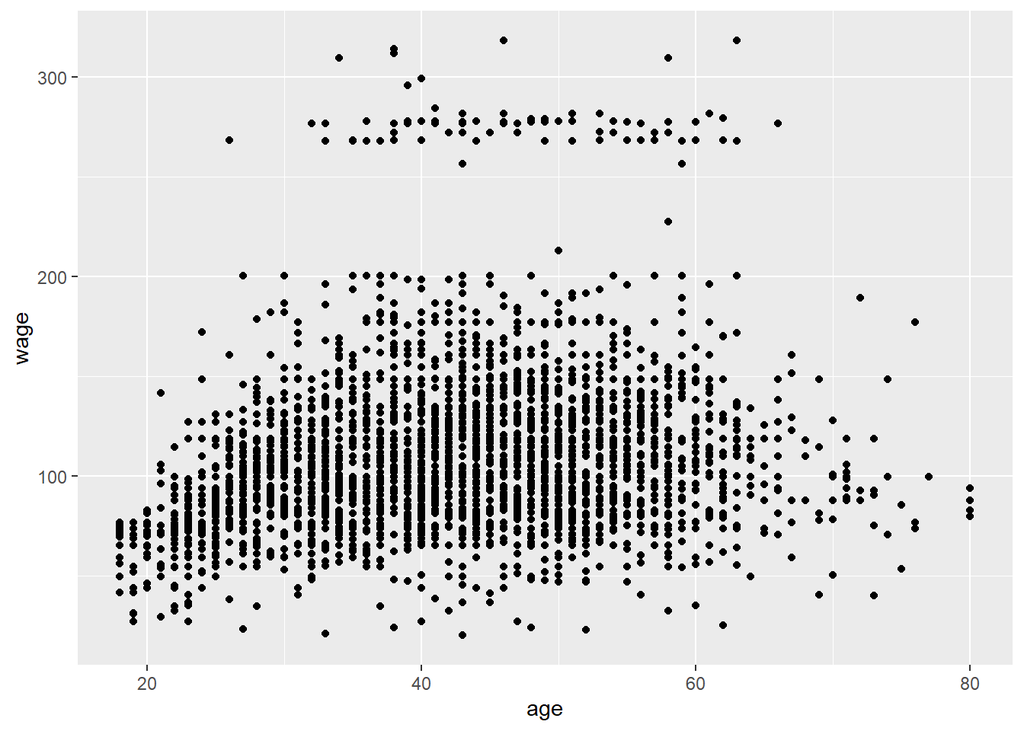

```r
library(ggplot2)
ggplot(data = Wage, mapping = aes(x = age, y = wage)) +
    geom_point()
```

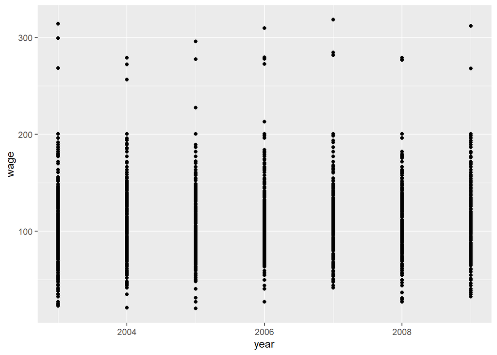

```r
ggplot(data = Wage, mapping = aes(x = year, y = wage)) +
    geom_point()
```

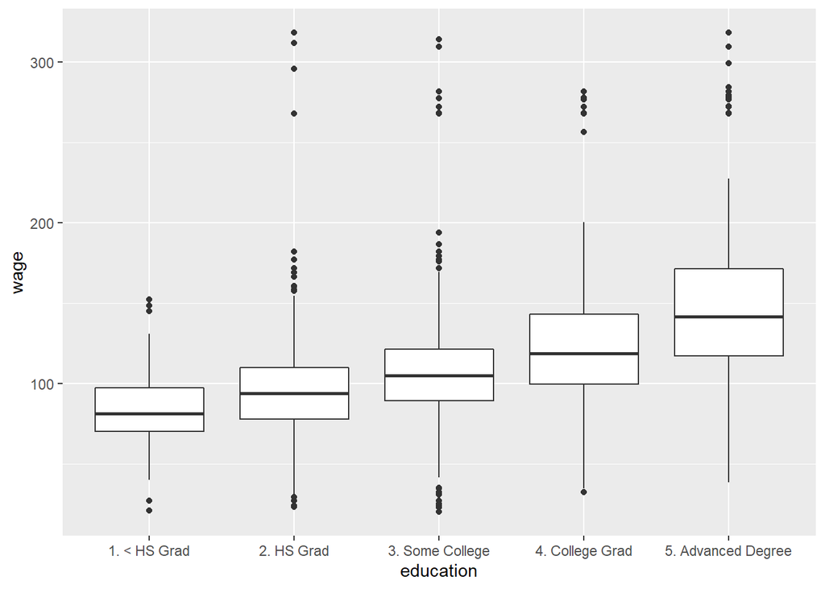

```r
#categorical variable
ggplot(Wage, aes(x = education, y = wage)) +
    geom_boxplot()
```

```r
#multiple linear regression model
mul_model <- lm(wage~age+year+education, data=Wage)
summary(mul_model)
```

[output not shown]

We then fit a GAM where ‘age’ and ‘year’ enter the model nonlinearly, whereas variable ‘education’ enters linearly.

```r
gam_mod <- gam(wage~s(age, k=6)+s(year, k=6)+education ,data = Wage)
summary(gam_mod)
```

```
##
## Family: gaussian
## Link function: identity
##
## Formula:
## wage ~ s(age, k = 6) + s(year, k = 6) + education
##
## Parametric coefficients:
##                             Estimate Std. Error t value Pr(>|t|)
## (Intercept)                   85.456      2.153  39.692  < 2e-16 ***
## education2. HS Grad           10.978      2.428   4.521  6.4e-06 ***
## education3. Some College      23.530      2.558   9.197  < 2e-16 ***
## education4. College Grad      38.159      2.543  15.005  < 2e-16 ***
## education5. Advanced Degree   62.559      2.760  22.668  < 2e-16 ***
## ---
## Signif. codes:  0 '***' 0.001 '**' 0.01 '*' 0.05 '.' 0.1 ' ' 1
##
## Approximate significance of smooth terms:
##           edf Ref.df     F  p-value
## s(age)  4.435  4.840 46.69  < 2e-16 ***
## s(year) 1.101  1.195 11.11 0.000379 ***
## ---
## Signif. codes:  0 '***' 0.001 '**' 0.01 '*' 0.05 '.' 0.1 ' ' 1
##
## R-sq.(adj) =   0.29   Deviance explained = 29.2%
## GCV = 1240.7  Scale est. = 1236.3    n = 3000
```

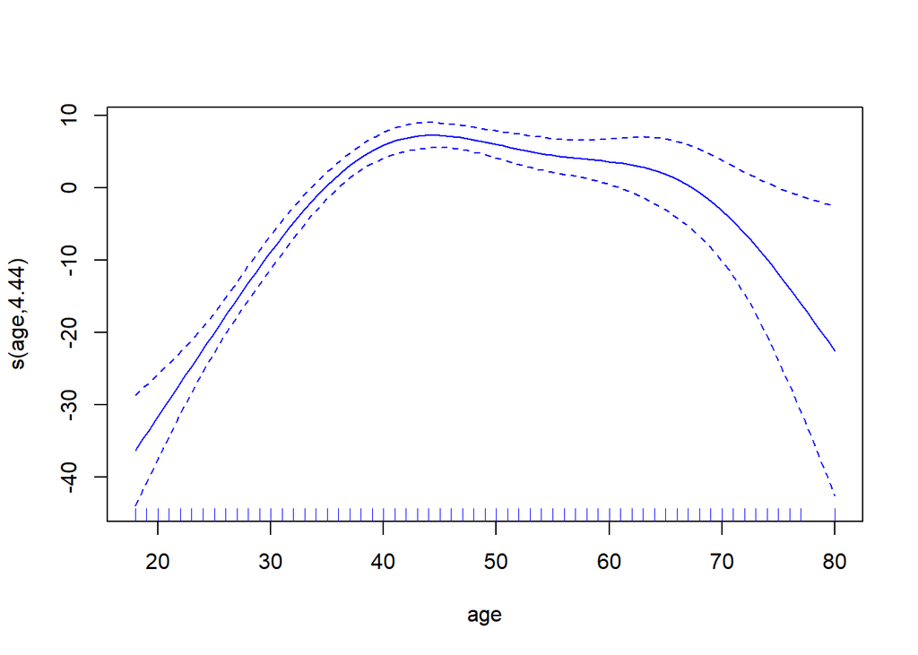

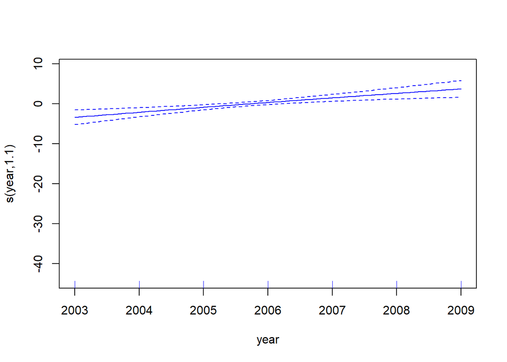

```r
plot(gam_mod, se=TRUE ,col="blue")
```

**Basis dimension choice for smooths**

*gam.check* runs a simple simulation based check on the basis dimensions, which can help to flag up terms for which k is too low. Grossly too small k will also be visible from partial residuals available with plot.gam.

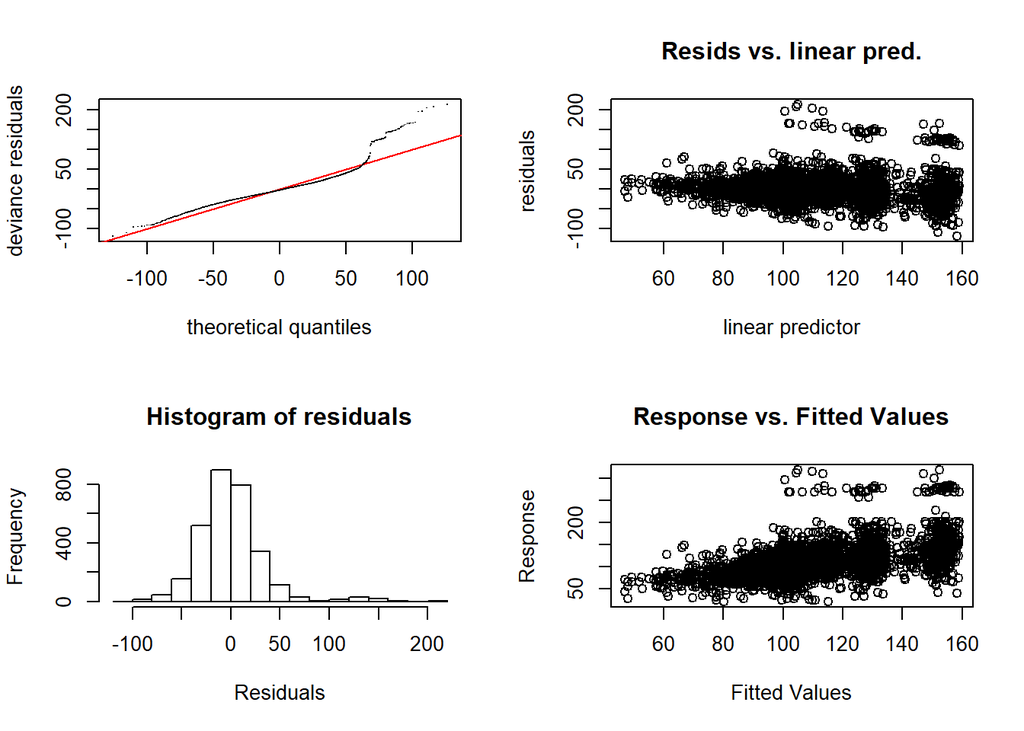

```
##
## Method: GCV   Optimizer: magic
## Smoothing parameter selection converged after 7 iterations.
## The RMS GCV score gradient at convergence was 0.002902862 .
## The Hessian was positive definite.
## Model rank =  15 / 15
##
## Basis dimension (k) checking results. Low p-value (k-index<1) may
## indicate that k is too low, especially if edf is close to k'.
##
##           k'  edf k-index p-value
## s(age)  5.00 4.44    0.98   0.075 .
## s(year) 5.00 1.10    1.02   0.790
## ---
## Signif. codes:  0 '***' 0.001 '**' 0.01 '*' 0.05 '.' 0.1 ' ' 1
```

```r
gam.check(gam_mod)
```

go to top